# Study 2

## (1) Description of Data Files

The posted data for this study consists of 1 compiled, deidentified data file (total *N* recruited = 151):

- 2 responses excluded prior to compiling this deidentified file because (1) 1 participant completed the study twice, so their second response was removed, and (2) 1 participant started the study twice but they did not continue beyond the consent page the 1st time, so their 2nd response was retained
- 34 participants excluded because they were not undergraduate students
- 13 participants were excluded because they failed at least 1 attention check

## (2) Descriptive Statistics

**Total *N*:** 102

*N* in each condition:

```
## cond
## strong   weak   <NA>
##     53     49      0
```

**Percentage by gender:**

```
## Gender
## female   male   <NA>
##     44     58      0
```

**Percentage by college class:**

```
## class
##  freshman    junior    senior sophomore      <NA>
##       9.8      28.4      32.4      29.4       0.0
```

**Percentage by college type:**

```
## collegetype
##           community   private    public      <NA>
##         0        13        27        62         0
```

*M*s and *SD*s:

```
##          n mean   sd  min max
## psm    101 4.88 1.26 1.50   7
## ldr    102 4.80 1.65 1.00   8
## income 102 3.30 1.98 1.00   8
## lti    102 4.38 1.44 1.33   7
```

**Correlations between income and subjective SES:**

```
##
##  Pearson's product-moment correlation
##
## data:  income and ldr
## t = 6.2963, df = 100, p-value = 8.188e-09
## alternative hypothesis: true correlation is not equal to 0
## 95 percent confidence interval:
##  0.3774471 0.6590017
## sample estimates:
##       cor
## 0.5328115
```

**Alphas:**

- **Perceptions of socioeconomic mobility (psm; manipulation check):** 0.88
- **Lay theories of intelligence (lti):** 0.88

## (3) Data Screening

### Random assignment checks

**(a) Unequal variance test, *t*-test, and *M*s and *SD*s for: subjective SES**

```
##
##  F test to compare two variances
##
## data:  ldr by cond
## F = 0.7755, num df = 52, denom df = 48, p-value = 0.3693
## alternative hypothesis: true ratio of variances is not equal to 1
## 95 percent confidence interval:
##  0.4410383 1.3549614
## sample estimates:
## ratio of variances
##          0.7755031
```

```
##
##  Two Sample t-test
##
## data:  ldr by cond
## t = 1.6181, df = 100, p-value = 0.1088
## alternative hypothesis: true difference in means is not equal to 0
## 95 percent confidence interval:
##  -0.1189248  1.1709078
## sample estimates:
## mean in group strong   mean in group weak
##             5.056604             4.530612
```

```
##
##  Descriptive statistics by group
## group: strong
##    vars  n mean   sd median trimmed  mad min max range skew kurtosis   se
## X1    1 53 5.06 1.54      5       5 1.48   2   8     6 0.19    -0.55 0.21
## ---------------------------------------------------------------------------
## group: weak
##    vars  n mean   sd median trimmed  mad min max range skew kurtosis   se
## X1    1 49 4.53 1.75      4    4.54 1.48   1   8     7 0.12    -0.68 0.25
```

**(b) Unequal variance test, *t*-test, and *M*s and *SD*s for: income**

```
##
##  F test to compare two variances
##
## data:  income by cond
## F = 0.66724, num df = 52, denom df = 48, p-value = 0.1542
## alternative hypothesis: true ratio of variances is not equal to 1
## 95 percent confidence interval:
##  0.3794675 1.1658032
## sample estimates:
## ratio of variances
##          0.6672396
```

```
##
##  Two Sample t-test
##
## data:  income by cond
## t = -0.30982, df = 100, p-value = 0.7573
## alternative hypothesis: true difference in means is not equal to 0
## 95 percent confidence interval:
##  -0.9037052  0.6595774
## sample estimates:
## mean in group strong   mean in group weak
##             3.245283             3.367347
```

```
##
##  Descriptive statistics by group
## group: strong
##    vars  n mean   sd median trimmed  mad min max range skew kurtosis   se
## X1    1 53 3.25 1.79      3    3.07 1.48   1   8     7 0.93     0.19 0.25
## ---------------------------------------------------------------------------
## group: weak
##    vars  n mean   sd median trimmed  mad min max range skew kurtosis   se
## X1    1 49 3.37 2.19      3    3.17 2.97   1   8     7 0.49    -0.85 0.31
```

### Manipulation checks

**(a) Unequal variance test, *t*-test, *M*s and *SD*s, and Cohen’s *D* for: Perceptions of socioeconomic mobility**

```
##
##  F test to compare two variances
##
## data:  psm by cond
## F = 0.6492, num df = 52, denom df = 47, p-value = 0.1299
## alternative hypothesis: true ratio of variances is not equal to 1
## 95 percent confidence interval:
##  0.3677144 1.1368849
## sample estimates:
## ratio of variances
##          0.6491993
```

```
##
##  Two Sample t-test
##
## data:  psm by cond
## t = 2.5121, df = 99, p-value = 0.01362
## alternative hypothesis: true difference in means is not equal to 0
## 95 percent confidence interval:
##  0.1287112 1.0963281
## sample estimates:
## mean in group strong   mean in group weak
##             5.169811             4.557292
```

```
##
##  Descriptive statistics by group
## group: strong
##    vars  n mean   sd median trimmed  mad min max range  skew kurtosis   se
## X1    1 53 5.17 1.09   5.25    5.27 0.74 1.5   7   5.5 -1.05     1.47 0.15
## ---------------------------------------------------------------------------
## group: weak
##    vars  n mean   sd median trimmed  mad min max range  skew kurtosis  se
## X1    1 48 4.56 1.35    4.5    4.58 1.85   2   7     5 -0.08     -1.1 0.2
```

**Cohen’s *d*:** 0.5

**(b) Perceptions of mobility by condition and SES**

```
##
## Call:
## lm(formula = psm ~ cond_c * income_c)
##
## Residuals:
##     Min      1Q  Median      3Q     Max
## -3.3104 -0.5616  0.0295  0.8892  2.4402
##
## Coefficients:
##                 Estimate Standardized Std. Error t value Pr(>|t|)
## (Intercept)      4.88053      0.00000    0.12136  40.216   <2e-16 ***
## cond_c           0.31085      0.24847    0.12151   2.558   0.0121 *
## income_c         0.08233      0.12950    0.06284   1.310   0.1933
## cond_c:income_c  0.08092      0.12802    0.06243   1.296   0.1980
## ---
## Signif. codes:  0 '***' 0.001 '**' 0.01 '*' 0.05 '.' 0.1 ' ' 1
##
## Residual standard error: 1.218 on 97 degrees of freedom
##   (1 observation deleted due to missingness)
## Multiple R-squared:  0.08687,    Adjusted R-squared:  0.05863
## F-statistic: 3.076 on 3 and 97 DF,  p-value: 0.03121
```

**95% confidence intervals for unstandardized regression coefficients:**

```
##                 Lower (estimate) Upper (estimate)
## (Intercept)                 4.64             5.12
## cond_c                      0.07             0.55
## income_c                   -0.04             0.21
## cond_c:income_c            -0.04             0.20
```

**(c) Unequal variance test, *t*-test, and *M*s and *SD*s for: LTI**

```
##
##  F test to compare two variances
##
## data:  lti by cond
## F = 0.85381, num df = 52, denom df = 48, p-value = 0.5757
## alternative hypothesis: true ratio of variances is not equal to 1
## 95 percent confidence interval:
##  0.4855728 1.4917807
## sample estimates:
## ratio of variances
##          0.8538106
```

```
##
##  Two Sample t-test
##
## data:  lti by cond
## t = 1.4879, df = 100, p-value = 0.1399
## alternative hypothesis: true difference in means is not equal to 0
## 95 percent confidence interval:
##  -0.1407295  0.9850370
## sample estimates:
## mean in group strong   mean in group weak
##             4.578616             4.156463
```

```
##
##  Descriptive statistics by group
## group: strong
##    vars  n mean   sd median trimmed  mad  min max range  skew kurtosis   se
## X1    1 53 4.58 1.38      5    4.67 1.48 1.33   7  5.67 -0.51    -0.51 0.19
## ---------------------------------------------------------------------------
## group: weak
##    vars  n mean   sd median trimmed  mad  min max range skew kurtosis   se
## X1    1 49 4.16 1.49      4    4.11 1.48 1.67   7  5.33 0.23    -0.94 0.21
```

### Correcting negative skew in anagram score

The raw anagram scores were highly negatively skewed (skew = -2.25). As such, they were subjected to a logarithmic transformation before being submitted to our analyses (see Ratcliff, 1993). This produced an acceptable level of skew (0.55), whereas using an inverse transformation did not (1.02).

## (4) Main Analyses

### Analyses with income and without covariates

**Correlation with persistence**

```
##
##  Pearson's product-moment correlation
##
## data:  t.acc and income
## t = 1.1952, df = 100, p-value = 0.2349
## alternative hypothesis: true correlation is not equal to 0
## 95 percent confidence interval:
##  -0.07759468  0.30608197
## sample estimates:
##      cor
## 0.118671
```

**Omnibus test:**

```
##
## Call:
## lm(formula = t.acc ~ cond_c * income_c)
##
## Residuals:
##     Min      1Q  Median      3Q     Max
## -1.1162 -0.3333 -0.1247  0.4192  0.9371
##
## Coefficients:
##                 Estimate Standardized Std. Error t value Pr(>|t|)
## (Intercept)      2.01844      0.00000    0.04806  41.999   <2e-16 ***
## cond_c           0.04597      0.09229    0.04810   0.956    0.342
## income_c         0.01773      0.07015    0.02490   0.712    0.478
## cond_c:income_c -0.06493     -0.25861    0.02473  -2.626    0.010 *
## ---
## Signif. codes:  0 '***' 0.001 '**' 0.01 '*' 0.05 '.' 0.1 ' ' 1
##
## Residual standard error: 0.4851 on 98 degrees of freedom
## Multiple R-squared:  0.08701,    Adjusted R-squared:  0.05906
## F-statistic: 3.113 on 3 and 98 DF,  p-value: 0.02975
```

**95% confidence intervals for unstandardized regression coefficients:**

```
##                 Lower (estimate) Upper (estimate)
## (Intercept)                 1.92             2.11
## cond_c                     -0.05             0.14
## income_c                   -0.03             0.07
## cond_c:income_c            -0.11            -0.02
```

**Simple slopes tests:**

```
##
## ** Estimated points of t.acc  **
##
##                       Low cond_c (-1 SD) High cond_c (+1 SD)
## Low income_c (-1 SD)              1.8082              2.1585
## High income_c (+1 SD)             2.1364              1.9707
##
##
##
## ** Simple Slopes analysis ( df= 98 ) **
##
##                       simple slope standard error t-value p.value
## Low income_c (-1 SD)        0.1745         0.0685    2.55   0.012 *
## High income_c (+1 SD)      -0.0825         0.0687   -1.20   0.233
## ---
## Signif. codes:  0 '***' 0.001 '**' 0.01 '*' 0.05 '.' 0.1 ' ' 1
##
##
##
## ** Bauer & Curran 95% CI **
##
##          lower CI upper CI
## income_c  -0.8848   4.1008
```

**CIs among low-income students:** 0.04, 0.31

**CIs among high-income students:** -0.22, 0.05

**Plot (with untransformed data):**

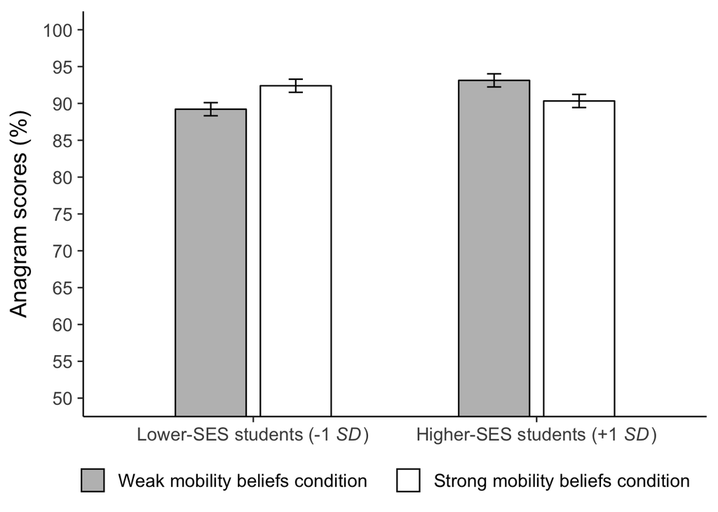

### Analyses with subjective SES and without covariates

**Correlation with persistence**

```
##
##  Pearson's product-moment correlation
##
## data:  t.acc and ladder
## t = -0.14597, df = 100, p-value = 0.8842
## alternative hypothesis: true correlation is not equal to 0
## 95 percent confidence interval:
##  -0.2084784  0.1803916
## sample estimates:
##        cor
## -0.0145953
```

**Omnibus test:**

```
##
## Call:
## lm(formula = t.acc ~ cond_c * ladder_c)
##
## Residuals:
##     Min      1Q  Median      3Q     Max
## -1.0665 -0.3272 -0.1560  0.4827  1.0325
##
## Coefficients:
##                 Estimate Standardized Std. Error t value Pr(>|t|)
## (Intercept)      2.04769      0.00000    0.04816  42.522  < 2e-16 ***
## cond_c           0.04576      0.09187    0.04819   0.950  0.34470
## ladder_c        -0.01205     -0.03983    0.02950  -0.408  0.68387
## cond_c:ladder_c -0.09629     -0.31555    0.02938  -3.277  0.00145 **
## ---
## Signif. codes:  0 '***' 0.001 '**' 0.01 '*' 0.05 '.' 0.1 ' ' 1
##
## Residual standard error: 0.4801 on 98 degrees of freedom
## Multiple R-squared:  0.106,  Adjusted R-squared:  0.07863
## F-statistic: 3.873 on 3 and 98 DF,  p-value: 0.01153
```

**95% confidence intervals for unstandardized regression coefficients:**

```
##                 Lower (estimate) Upper (estimate)
## (Intercept)                 1.95             2.14
## cond_c                     -0.05             0.14
## ladder_c                   -0.07             0.05
## cond_c:ladder_c            -0.15            -0.04
```

**Simple slopes tests:**

```
##
## ** Estimated points of t.acc  **
##
##                       Low cond_c (-1 SD) High cond_c (+1 SD)
## Low ladder_c (-1 SD)              1.8618              2.2734
## High ladder_c (+1 SD)             2.1417              1.9139
##
##
##
## ** Simple Slopes analysis ( df= 98 ) **
##
##                       simple slope standard error t-value p.value
## Low ladder_c (-1 SD)        0.2050         0.0687    2.98  0.0036 **
## High ladder_c (+1 SD)      -0.1134         0.0682   -1.66  0.0993 .
## ---
## Signif. codes:  0 '***' 0.001 '**' 0.01 '*' 0.05 '.' 0.1 ' ' 1
##
##
##
## ** Bauer & Curran 95% CI **
##
##          lower CI upper CI
## ladder_c  -0.5647   2.0303
```

**CIs among low subjective SES students:** 0.07, 0.34

**CIs among high subjective SES students:** -0.25, 0.02

### Analyses with income and covariates

**Omnibus test:**

```
##
## Call:
## lm(formula = t.acc ~ cond_c * income_c + lti_c * income_c)
##
## Residuals:
##     Min      1Q  Median      3Q     Max
## -0.9724 -0.3372 -0.1449  0.3953  0.9384
##
## Coefficients:
##                 Estimate Standardized Std. Error t value Pr(>|t|)
## (Intercept)      2.01294      0.00000    0.04868  41.347  < 2e-16 ***
## cond_c           0.03649      0.07327    0.04847   0.753  0.45336
## income_c         0.02466      0.09760    0.02518   0.979  0.32987
## lti_c            0.05719      0.16469    0.03436   1.664  0.09928 .
## cond_c:income_c -0.06511     -0.25934    0.02473  -2.633  0.00988 **
## income_c:lti_c  -0.01012     -0.05664    0.01733  -0.584  0.56043
## ---
## Signif. codes:  0 '***' 0.001 '**' 0.01 '*' 0.05 '.' 0.1 ' ' 1
##
## Residual standard error: 0.4825 on 96 degrees of freedom
## Multiple R-squared:  0.1153, Adjusted R-squared:  0.06926
## F-statistic: 2.503 on 5 and 96 DF,  p-value: 0.03554
```

**95% confidence intervals for unstandardized regression coefficients:**

```
##                 Lower (estimate) Upper (estimate)
## (Intercept)                 1.92             2.11
## cond_c                     -0.06             0.13
## income_c                   -0.03             0.07
## lti_c                      -0.01             0.13
## cond_c:income_c            -0.11            -0.02
## income_c:lti_c             -0.04             0.02
```

**Simple slopes tests:**

```
##
## ** Estimated points of t.acc  **
##
##                       Low cond_c (-1 SD) High cond_c (+1 SD)
## Low income_c (-1 SD)              1.7981              2.1302
## High income_c (+1 SD)             2.1545              1.9690
##
##
##
## ** Simple Slopes analysis ( df= 96 ) **
##
##                       simple slope standard error t-value p.value
## Low income_c (-1 SD)        0.1653         0.0683    2.42   0.017 *
## High income_c (+1 SD)      -0.0924         0.0695   -1.33   0.187
## ---
## Signif. codes:  0 '***' 0.001 '**' 0.01 '*' 0.05 '.' 0.1 ' ' 1
##
##
##
## ** Bauer & Curran 95% CI **
##
##          lower CI upper CI
## income_c  -1.1013   3.6971
```

**CIs among low-income students:** 0.03, 0.3

**CIs among high-income students:** -0.23, 0.05

### Analyses with subjective SES and covariates

**Omnibus test:**

```
##
## Call:
## lm(formula = t.acc ~ cond_c * ladder_c + lti_c * ladder_c)
##
## Residuals:
##     Min      1Q  Median      3Q     Max
## -0.9983 -0.3356 -0.1360  0.4939  0.9294
##
## Coefficients:
##                  Estimate Standardized Std. Error t value Pr(>|t|)
## (Intercept)      2.050257     0.000000   0.048064  42.657  < 2e-16 ***
## cond_c           0.042704     0.085741   0.048763   0.876  0.38335
## ladder_c        -0.008152    -0.026948   0.029541  -0.276  0.78318
## lti_c            0.035466     0.102127   0.033781   1.050  0.29641
## cond_c:ladder_c -0.094119    -0.308445   0.029440  -3.197  0.00188 **
## ladder_c:lti_c   0.024998     0.126755   0.018901   1.323  0.18912
## ---
## Signif. codes:  0 '***' 0.001 '**' 0.01 '*' 0.05 '.' 0.1 ' ' 1
##
## Residual standard error: 0.4784 on 96 degrees of freedom
## Multiple R-squared:  0.1302, Adjusted R-squared:  0.08492
## F-statistic: 2.875 on 5 and 96 DF,  p-value: 0.01837
```

**95% confidence intervals for unstandardized regression coefficients:**

```
##                 Lower (estimate) Upper (estimate)
## (Intercept)                 1.95             2.15
## cond_c                     -0.05             0.14
## ladder_c                   -0.07             0.05
## lti_c                      -0.03             0.10
## cond_c:ladder_c            -0.15            -0.04
## ladder_c:lti_c             -0.01             0.06
```

**Simple slopes tests:**

```
##
## ** Estimated points of t.acc  **
##
##                       Low cond_c (-1 SD) High cond_c (+1 SD)
## Low ladder_c (-1 SD)              1.8646              2.2629
## High ladder_c (+1 SD)             2.1502              1.9234
##
##
##
## ** Simple Slopes analysis ( df= 96 ) **
##
##                       simple slope standard error t-value p.value
## Low ladder_c (-1 SD)        0.1983         0.0698    2.84  0.0055 **
## High ladder_c (+1 SD)      -0.1129         0.0680   -1.66  0.1002
## ---
## Signif. codes:  0 '***' 0.001 '**' 0.01 '*' 0.05 '.' 0.1 ' ' 1
##
##
##
## ** Bauer & Curran 95% CI **
##
##          lower CI upper CI
## ladder_c  -0.6453   2.0491
```

**CIs among low subjective SES students:** 0.06, 0.34

**CIs among high subjective SES students:** -0.25, 0.02

### Analyses with gender

**T-test:**

```
##
##  F test to compare two variances
##
## data:  t.acc by Gender
## F = 0.74584, num df = 43, denom df = 57, p-value = 0.3176
## alternative hypothesis: true ratio of variances is not equal to 1
## 95 percent confidence interval:
##  0.4280835 1.3292681
## sample estimates:
## ratio of variances
##          0.7458361
```

```
##
##  Two Sample t-test
##
## data:  t.acc by Gender
## t = 0.52107, df = 100, p-value = 0.6035
## alternative hypothesis: true difference in means is not equal to 0
## 95 percent confidence interval:
##  -0.1468014  0.2513809
## sample estimates:
## mean in group female   mean in group male
##             2.052134             1.999845
```

```
##
##  Descriptive statistics by group
## group: female
##    vars  n mean   sd median trimmed  mad  min  max range skew kurtosis   se
## X1    1 44 2.05 0.46   1.93    2.04 0.27 1.38 2.79  1.41  0.7    -0.95 0.07
## ---------------------------------------------------------------------------
## group: male
##    vars  n mean   sd median trimmed  mad min  max range skew kurtosis   se
## X1    1 58    2 0.53   1.84    1.99 0.34   1 2.79  1.79 0.49    -1.12 0.07
```

#### Analyses with income

**Omnibus test:**

```
##
## Call:
## lm(formula = t.acc ~ cond_c * income_c * gender_c)
##
## Residuals:
##     Min      1Q  Median      3Q     Max
## -1.2204 -0.3400 -0.1186  0.2789  0.9309
##
## Coefficients:
##                          Estimate Standardized Std. Error t value Pr(>|t|)
## (Intercept)               2.02624      0.00000    0.04811  42.115   <2e-16 ***
## cond_c                    0.05395      0.10832    0.04813   1.121   0.2652
## income_c                  0.01047      0.04142    0.02577   0.406   0.6855
## gender_c                 -0.02095     -0.04171    0.04863  -0.431   0.6675
## cond_c:income_c          -0.05754     -0.22917    0.02566  -2.242   0.0273 *
## cond_c:gender_c           0.04560      0.09067    0.04865   0.937   0.3510
## income_c:gender_c        -0.04866     -0.19638    0.02555  -1.905   0.0599 .
## cond_c:income_c:gender_c -0.01308     -0.05318    0.02538  -0.515   0.6076
## ---
## Signif. codes:  0 '***' 0.001 '**' 0.01 '*' 0.05 '.' 0.1 ' ' 1
##
## Residual standard error: 0.483 on 94 degrees of freedom
## Multiple R-squared:  0.1321, Adjusted R-squared:  0.06747
## F-statistic: 2.044 on 7 and 94 DF,  p-value: 0.05747
```

**95% confidence intervals for unstandardized regression coefficients:**

```
##                          Lower (estimate) Upper (estimate)
## (Intercept)                          1.93             2.12
## cond_c                              -0.04             0.15
## income_c                            -0.04             0.06
## gender_c                            -0.12             0.08
## cond_c:income_c                     -0.11            -0.01
## cond_c:gender_c                     -0.05             0.14
## income_c:gender_c                   -0.10             0.00
## cond_c:income_c:gender_c            -0.06             0.04
```

#### Analyses with subjective SES

**Omnibus test:**

```
##
## Call:
## lm(formula = t.acc ~ cond_c * ladder_c * gender_c)
##
## Residuals:
##     Min      1Q  Median      3Q     Max
## -1.1086 -0.3134 -0.1469  0.4763  0.9407
##
## Coefficients:
##                           Estimate Standardized Std. Error t value Pr(>|t|)
## (Intercept)               2.055496     0.000000   0.047597  43.185  < 2e-16 ***
## cond_c                    0.051100     0.102598   0.047625   1.073 0.286033
## ladder_c                 -0.014691    -0.048566   0.029194  -0.503 0.615976
## gender_c                 -0.001715    -0.003413   0.047937  -0.036 0.971536
## cond_c:ladder_c          -0.100259    -0.328565   0.029069  -3.449 0.000844 ***
## cond_c:gender_c           0.056805     0.112966   0.047972   1.184 0.239345
## ladder_c:gender_c        -0.026619    -0.087595   0.029252  -0.910 0.365153
## cond_c:ladder_c:gender_c -0.065479    -0.216213   0.029127  -2.248 0.026911 *
## ---
## Signif. codes:  0 '***' 0.001 '**' 0.01 '*' 0.05 '.' 0.1 ' ' 1
##
## Residual standard error: 0.4734 on 94 degrees of freedom
## Multiple R-squared:  0.1663, Adjusted R-squared:  0.1042
## F-statistic: 2.678 on 7 and 94 DF,  p-value: 0.01425
```

**95% confidence intervals for unstandardized regression coefficients:**

```
##                          Lower (estimate) Upper (estimate)
## (Intercept)                          1.96             2.15
## cond_c                              -0.04             0.15
## ladder_c                            -0.07             0.04
## gender_c                            -0.10             0.09
## cond_c:ladder_c                     -0.16            -0.04
## cond_c:gender_c                     -0.04             0.15
## ladder_c:gender_c                   -0.08             0.03
## cond_c:ladder_c:gender_c            -0.12            -0.01
```

**Simple effects:**

```
##
## ** Estimated points of t.acc  **
##
##                                                   Low cond_c (-1 SD) High cond_c (+1 SD)
## Low gender_c (-1 SD) , Low ladder_c (-1 SD) [1]               1.9849              2.0905
## Low gender_c (-1 SD) , High ladder_c (+1 SD) [2]              2.1404              2.0130
## High gender_c (+1 SD) , Low ladder_c (-1 SD) [3]              1.7391              2.5046
## High gender_c (+1 SD) , High ladder_c (+1 SD) [4]             2.1523              1.8191
##
##
##
## ** Simple Slopes analysis ( df= 94 ) **
##
##                                                   simple slope standard error t-value p.value
## Low gender_c (-1 SD) , Low ladder_c (-1 SD) [1]         0.0526         0.0927    0.57  0.5721
## Low gender_c (-1 SD) , High ladder_c (+1 SD) [2]       -0.0634         0.0952   -0.67  0.5070
## High gender_c (+1 SD) , Low ladder_c (-1 SD) [3]        0.3812         0.0991    3.85  0.0002 ***
## High gender_c (+1 SD) , High ladder_c (+1 SD) [4]      -0.1659         0.0956   -1.74  0.0860 .
## ---
## Signif. codes:  0 '***' 0.001 '**' 0.01 '*' 0.05 '.' 0.1 ' ' 1
##
##
##
## ** Slope Difference Test (( df= 94 ); Dawson & Richter, 2006) **
##                                                                                                          t-value
## High gender_c (+1 SD) , High ladder_c (+1 SD) [4]  vs.  High gender_c (+1 SD) , Low ladder_c (-1 SD) [3] -3.9245
## High gender_c (+1 SD) , High ladder_c (+1 SD) [4]  vs.  Low gender_c (-1 SD) , High ladder_c (+1 SD) [2] -0.7574
## High gender_c (+1 SD) , High ladder_c (+1 SD) [4]  vs.  Low gender_c (-1 SD) , Low ladder_c (-1 SD) [1]  -1.6382
## High gender_c (+1 SD) , Low ladder_c (-1 SD) [3]  vs.  Low gender_c (-1 SD) , Low ladder_c (-1 SD) [1]    2.4299
## High gender_c (+1 SD) , Low ladder_c (-1 SD) [3]  vs.  Low gender_c (-1 SD) , High ladder_c (+1 SD) [2]   3.2304
## Low gender_c (-1 SD) , High ladder_c (+1 SD) [2]  vs.  Low gender_c (-1 SD) , Low ladder_c (-1 SD) [1]   -0.8321
##                                                                                                          p.value
## High gender_c (+1 SD) , High ladder_c (+1 SD) [4]  vs.  High gender_c (+1 SD) , Low ladder_c (-1 SD) [3]  0.0002
## High gender_c (+1 SD) , High ladder_c (+1 SD) [4]  vs.  Low gender_c (-1 SD) , High ladder_c (+1 SD) [2]  0.4507
## High gender_c (+1 SD) , High ladder_c (+1 SD) [4]  vs.  Low gender_c (-1 SD) , Low ladder_c (-1 SD) [1]   0.1047
## High gender_c (+1 SD) , Low ladder_c (-1 SD) [3]  vs.  Low gender_c (-1 SD) , Low ladder_c (-1 SD) [1]    0.0170
## High gender_c (+1 SD) , Low ladder_c (-1 SD) [3]  vs.  Low gender_c (-1 SD) , High ladder_c (+1 SD) [2]   0.0017
## Low gender_c (-1 SD) , High ladder_c (+1 SD) [2]  vs.  Low gender_c (-1 SD) , Low ladder_c (-1 SD) [1]    0.4074
##                                                                                                              Bonferroni.p
## High gender_c (+1 SD) , High ladder_c (+1 SD) [4]  vs.  High gender_c (+1 SD) , Low ladder_c (-1 SD) [3]           0.0010
## High gender_c (+1 SD) , High ladder_c (+1 SD) [4]  vs.  Low gender_c (-1 SD) , High ladder_c (+1 SD) [2]           1.0000
## High gender_c (+1 SD) , High ladder_c (+1 SD) [4]  vs.  Low gender_c (-1 SD) , Low ladder_c (-1 SD) [1]            0.6283
## High gender_c (+1 SD) , Low ladder_c (-1 SD) [3]  vs.  Low gender_c (-1 SD) , Low ladder_c (-1 SD) [1]             0.1020
## High gender_c (+1 SD) , Low ladder_c (-1 SD) [3]  vs.  Low gender_c (-1 SD) , High ladder_c (+1 SD) [2]            0.0102
## Low gender_c (-1 SD) , High ladder_c (+1 SD) [2]  vs.  Low gender_c (-1 SD) , Low ladder_c (-1 SD) [1]             1.0000
##
## High gender_c (+1 SD) , High ladder_c (+1 SD) [4]  vs.  High gender_c (+1 SD) , Low ladder_c (-1 SD) [3] ***
## High gender_c (+1 SD) , High ladder_c (+1 SD) [4]  vs.  Low gender_c (-1 SD) , High ladder_c (+1 SD) [2]
## High gender_c (+1 SD) , High ladder_c (+1 SD) [4]  vs.  Low gender_c (-1 SD) , Low ladder_c (-1 SD) [1]
## High gender_c (+1 SD) , Low ladder_c (-1 SD) [3]  vs.  Low gender_c (-1 SD) , Low ladder_c (-1 SD) [1]
## High gender_c (+1 SD) , Low ladder_c (-1 SD) [3]  vs.  Low gender_c (-1 SD) , High ladder_c (+1 SD) [2]  *
## Low gender_c (-1 SD) , High ladder_c (+1 SD) [2]  vs.  Low gender_c (-1 SD) , Low ladder_c (-1 SD) [1]
## ---
## Signif. codes:  0 '***' 0.001 '**' 0.01 '*' 0.05 '.' 0.1 ' ' 1
```

**CIs among female low subjective SES students:** -0.13, 0.24

**CIs among female high subjective SES students:** -0.25, 0.13

**CIs among male low subjective SES students:** 0.18, 0.58

**CIs among male high subjective SES students:** -0.36, 0.02